# SF-seq QAA

**Assigned Files**

34_4H_both 11_2H_both

# Part 1 - Quality

## (1) FastQC of the reads.

Using FastQC on Talapas, produce plots of quality score distributions for forward and reverse reads. Also, produce plots of the per-base N content, and comment on whether or not they are consistent with the quality score plots.

**Run FastQC**

```
fastqc /projects/bgmp/2017_sequencing/demultiplexed/34_4H_both_S24_L008_R* /projects/bgmp/2017_sequencing/demultiplexed/11_2H_both_S9_L008_R* -o jobs/624_ps1/
```

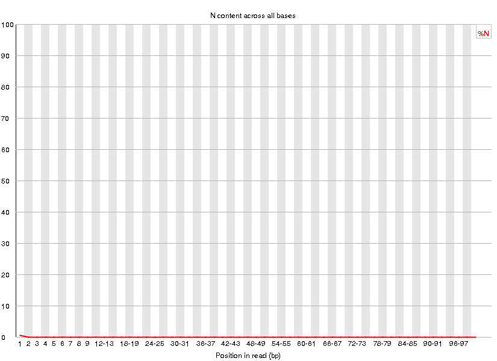

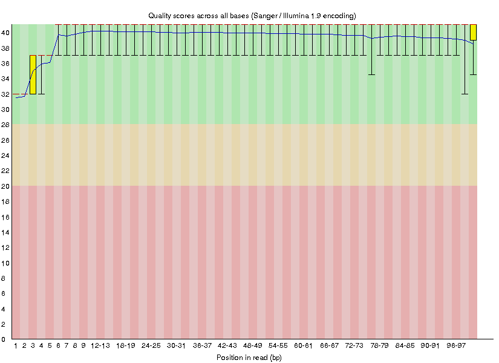

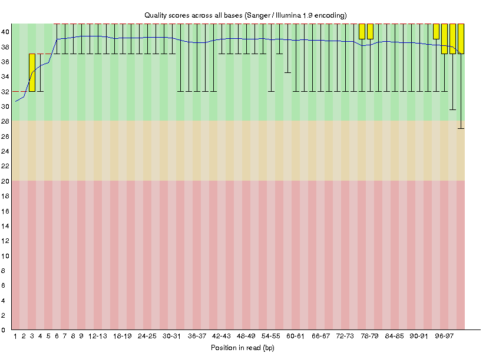

```r
myimages<-list.files("/home/christian/gdrive/School/bi624/ps1/mdw/", pattern = "11_2H*", full.names = TRUE)
include_graphics(myimages)
```

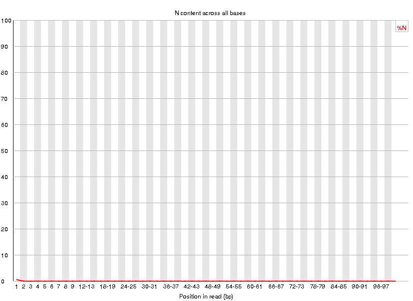

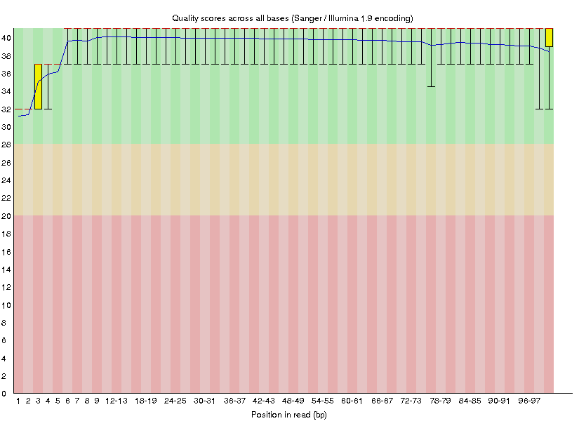

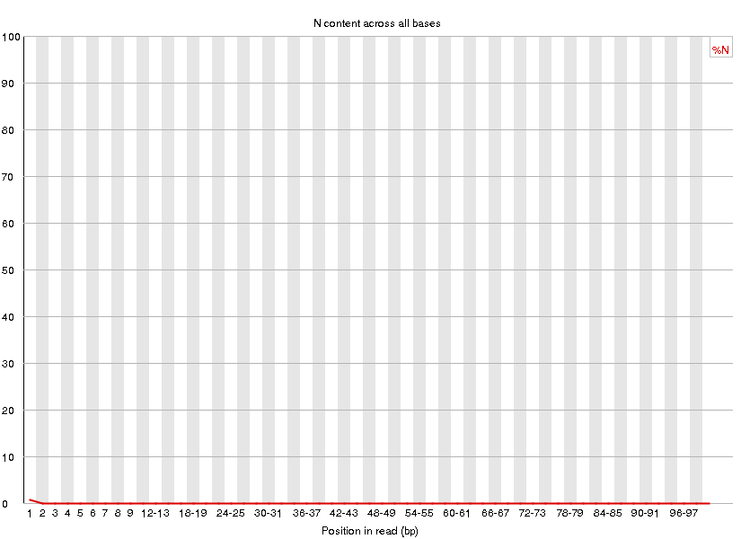

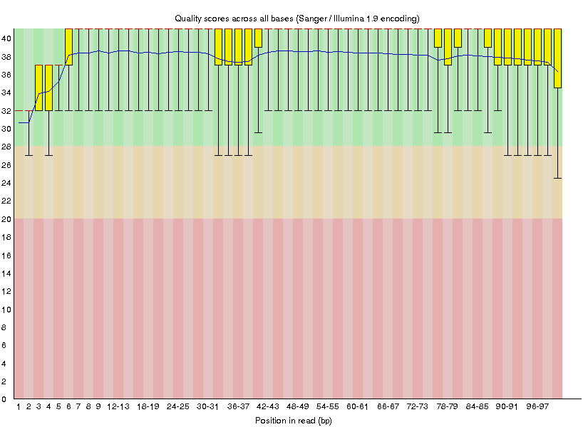

```r
myimages<-list.files("/home/christian/gdrive/School/bi624/ps1/mdw/", pattern = "34_4H*", full.names = TRUE)
include_graphics(myimages)
```

**Statistics for Library 34_4H** **A)** Read 1 N Content Per Base **B)** Read 1 Quality Score Per Base **C)** Read 2 N Content Per Base **D)** Read 2 Quality Score Per Base

*The small N content in the begining of the reads does seem to be reflected in the quality distribution of the reads. FastQC is faster, probably because it is written in a compiled language.*

## (2) Personal Quality Plots

Run your quality score plotting script from the index hopping assignment. Describe how the FastQC quality score distribution plots compare to your own. If different, propose an explanation. Also, does the runtime differ? If so, why?

**Run Quality Info Collection**

```
cd ~/jobs/624_ps1
FASTQ="/projects/bgmp/2017_sequencing/demultiplexed"
python index_qual.py -1 $FASTQ/11_2H_both_S9_L008_R1_001.fastq.gz -4 $FASTQ/11_2H_both_S9_L008_R2_001.fastq.gz -g -o .
python index_qual.py -1 $FASTQ/34_4H_both_S24_L008_R1_001.fastq.gz -4 $FASTQ/34_4H_both_S24_L008_R2_001.fastq.gz -g -o .
```

**Read in and print metadata**

```r
library(jsonlite)
library(reshape2)
base11=fromJSON('/home/christian/gdrive/School/bi624/ps1/11_2H_result')
base34=fromJSON('/home/christian/gdrive/School/bi624/ps1/34_4H_results')
qual11=base11$qual_info
rd_avg11=t(qual11$read_avg_dist)
qual34=base34$qual_info
rd_avg34=t(qual34$read_avg_dist)
print(base11$metadata)
```

```
## $read1_file
## [1] "/projects/bgmp/2017_sequencing/demultiplexed//11_2H_both_S9_L008_R1_001.fastq.gz"
##
## $read2_file
## [1] "/projects/bgmp/2017_sequencing/demultiplexed//11_2H_both_S9_L008_R2_001.fastq.gz"
##
## $rev_comp
## [1] TRUE
##
## $gzip
## [1] TRUE
##
## $out_dir
## [1] "./11_2H_result"
```

```r
print(base34$metadata)
```

```
## $read1_file
## [1] "/projects/bgmp/2017_sequencing/demultiplexed//34_4H_both_S24_L008_R1_001.fastq.gz"
##
## $read2_file
## [1] "/projects/bgmp/2017_sequencing/demultiplexed//34_4H_both_S24_L008_R2_001.fastq.gz"
##
## $rev_comp
## [1] TRUE
##
## $gzip
## [1] TRUE
##
## $out_dir
## [1] "./34_4H_results"
```

```r
rdf_melt11 <- melt(rd_avg11)
rdf_melt34 <- melt(rd_avg34)

rr1 <- ggplot(data=subset(rdf_melt11, Var2==1 & value != is.na(Var2)), aes(x=Var1, y=value))+
 geom_col(color = "black")+
 scale_y_log10()+
 xlab("Avg Phred Per Read")+ylab("Counts")

rr2 <- ggplot(data=subset(rdf_melt11, Var2==2 & value != is.na(Var2)), aes(x=Var1, y=value))+
 geom_col(width = 1, color = "black")+
 scale_y_log10()+
 xlab("Avg Phred Per Read")+ylab("Counts")

rr3 <- ggplot(data=subset(rdf_melt34, Var2==1 & value != is.na(Var2)), aes(x=Var1, y=value))+
 geom_col(color = "black")+
 scale_y_log10()+
 xlab("Avg Phred Per Read")+ylab("Counts")

rr4 <- ggplot(data=subset(rdf_melt34, Var2==2 & value != is.na(Var2)), aes(x=Var1, y=value))+
 geom_col(width = 1, color = "black")+
 scale_y_log10()+
 xlab("Avg Phred Per Read")+ylab("Counts")

pos_melt11=melt(qual11$pos_avg_dist)
pos_melt11=transform(pos_melt11, i = ave(L1, L1, FUN = seq_along))
pos_melt34=melt(qual34$pos_avg_dist)
pos_melt34=transform(pos_melt34, i = ave(L1, L1, FUN = seq_along))

pr1 <- ggplot(data=subset(pos_melt11, L1==1), aes(x=i, y=value))+
 geom_col(width = 1, color = "black")+
 xlab("Position")+ylab("Avg Base Phred")

pr2 <- ggplot(data=subset(pos_melt11, L1==2), aes(x=i, y=value))+
 geom_col(width = 1, color = "black")+
 xlab("Position")+ylab("Avg Base Phred")

pr3 <- ggplot(data=subset(pos_melt34, L1==1), aes(x=i, y=value))+
 geom_col(width = 1, color = "black")+
 xlab("Position")+ylab("Avg Base Phred")

pr4 <- ggplot(data=subset(pos_melt34, L1==2), aes(x=i, y=value))+
 geom_col(width = 1, color = "black")+
 xlab("Position")+ylab("Avg Base Phred")
```

**Average Score per Read**

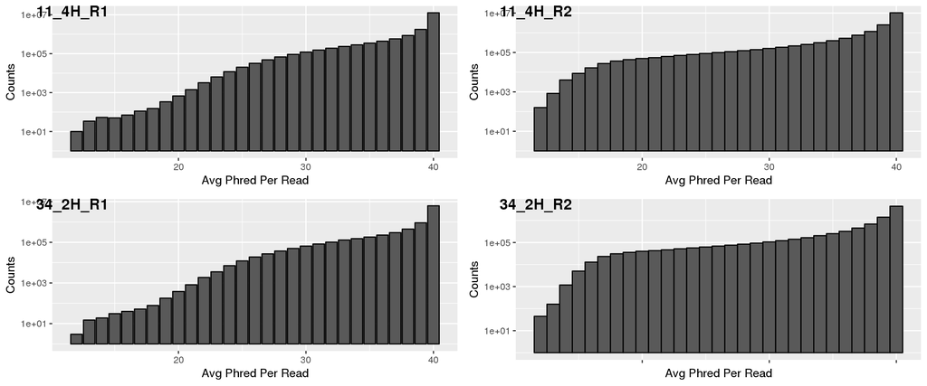

**Average Score per Base Position** The average phred score per base position in the reads. Note that the method of calculating the average was $m_n=m_{n-1}+{a_n-m_{n-1} \over n}$, in order to use O(n) space.

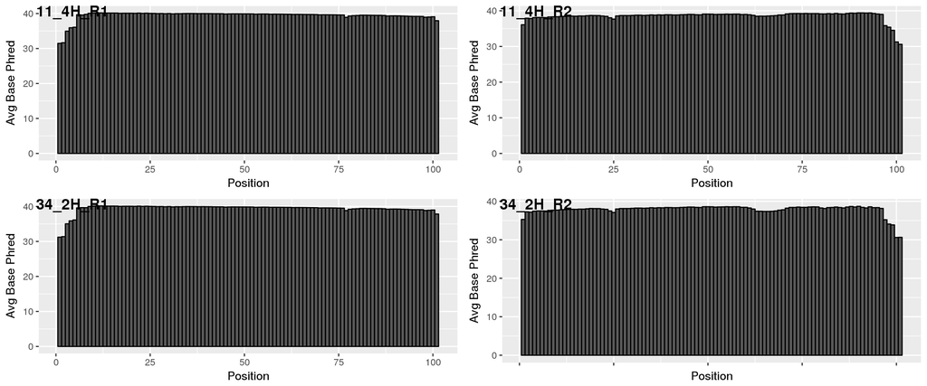

**Histogram of Average Score per Base Position** Note that the method of calculating the average was $m_n=m_{n-1}+{a_n-m_{n-1} \over n}$, in order to use O(n) space.

*As far as the quality per base the two programs show the same trend. The only differance is that Read 2 was flipped in my plots.*

# Part 2 – Adaptor trimming comparison

## (1) Adapter Trimming

Look into the adaptor trimming options for cutadapt, process_shortreads, and Trimmomatic (all on Talapas), and briefly describe the differences. Pick one of these to properly trim adapter sequences. Use default settings. What proportion of reads (both forward and reverse) was trimmed?

**cutadapt** A python program that finds and removes adapter sequences, primers, poly-A tails and other types of unwanted sequence in an error-tolerant way from high-throughput sequencing reads. Also, multiplexed, paired-end reads and colorspace data is supported.

**process_shortreads** Is a part of the Stacks suite, which quality checks and corrects tags and demultipledxes them. Then uses a sliding window approch to trim data.

**Trimmomatic** A Java program that has a variety of trimming algorithms, such as MAXINFO which maximizes length and quality. It works on both paired and single reads.

*Used cutadapt*

```
#!/bin/bash
#SBATCH --partition=short        ### Partition (like a queue in PBS)
#SBATCH --job-name=cutadapt      ### Job Name
#SBATCH --output=cut.out         ### File in which to store job output
#SBATCH --error=cut.err          ### File in which to store job error messages
#SBATCH --time=0-23:59:00       ### Wall clock time limit in Days-HH:MM:SS
#SBATCH --nodes=1               ### Node count required for the job
#SBATCH --ntasks-per-node=28     ### Nuber of tasks to be launched per Node
#SBATCH --mail-type=ALL
#SBATCH --mail-user=bio.erikson@gmail.com

FASTQ="/projects/bgmp/2017_sequencing/demultiplexed"
ml easybuild  icc/2017.1.132-GCC-6.3.0-2.27  impi/2017.1.132 cutadapt/1.14-Python-2.7.13
cutadapt \
            -a GATCGGAAGAGCACACGTCTGAACTCCAGTCACNNNNNNNNATCTCGTATGCCGTCTTCTGCTTG \
            -A GATCGGAAGAGCGTCGTGTAGGGAAAGAGTGTNNNNNNNNGTGTAGATCTCGGTGGTCGCCGTATCATT \
            $FASTQ/11_2H_both_S9_L008_R1_001.fastq.gz\
            $FASTQ/11_2H_both_S9_L008_R2_001.fastq.gz \
            -o trimmed_11_2H.1.fastq.gz -p trimmed_11_2H.2.fastq.gz
cutadapt \
            -a GATCGGAAGAGCACACGTCTGAACTCCAGTCACNNNNNNNNATCTCGTATGCCGTCTTCTGCTTG \
            -A GATCGGAAGAGCGTCGTGTAGGGAAAGAGTGTNNNNNNNNGTGTAGATCTCGGTGGTCGCCGTATCATT \
            $FASTQ/34_4H_both_S9_L008_R1_001.fastq.gz\
            $FASTQ/34_4H_both_S9_L008_R2_001.fastq.gz \
            -o trimmed_34_4H.1.fastq.gz -p trimmed_34_4H.2.fastq.gz
```

Sanity check: Use your Unix skills to search for the adapter sequences in your datasets and confirm the expected sequence orientations.

```
zcat 11_2H_both_S9_L008_R2_001.fastq.gz | grep GATCGGAAGAGCGTCGTGTAGGGAAAGAGTGT | wc -l #rev_sen_r2
27801
zcat 11_2H_both_S9_L008_R1_001.fastq.gz | grep GATCGGAAGAGCACACGTCTGAACTCCAGTCAC | wc -l #anti_r1
24633
```

## (2) Plots of Length of Adapter Trimmed Reads

Plot the trimmed read length distributions for both forward and reverse reads (on the same plot). If necessary, consult Assignment 5 (Block 1) from Bi 623 to refresh your memory.

```
zcat ./trimmed_11_2h.1.fasta.gz| sed -n '2~4p' | awk 'BEGIN{SEQ=0};/./{print length($0)};'| sort -g | uniq -c > 11_2h_r1.len
zcat ./trimmed_11_2h.2.fasta.gz| sed -n '2~4p' | awk 'BEGIN{SEQ=0};/./{print length($0)};'| sort -g | uniq -c > 11_2h_r2.len'
zcat ./trimmed_34_4h.1.fasta.gz| sed -n '2~4p' | awk 'BEGIN{SEQ=0};/./{print length($0)};'| sort -g | uniq -c > 34_4h_r1.len
zcat ./trimmed_34_4h.2.fasta.gz| sed -n '2~4p' | awk 'BEGIN{SEQ=0};/./{print length($0)};'| sort -g | uniq -c > 34_4h_r2.len
```

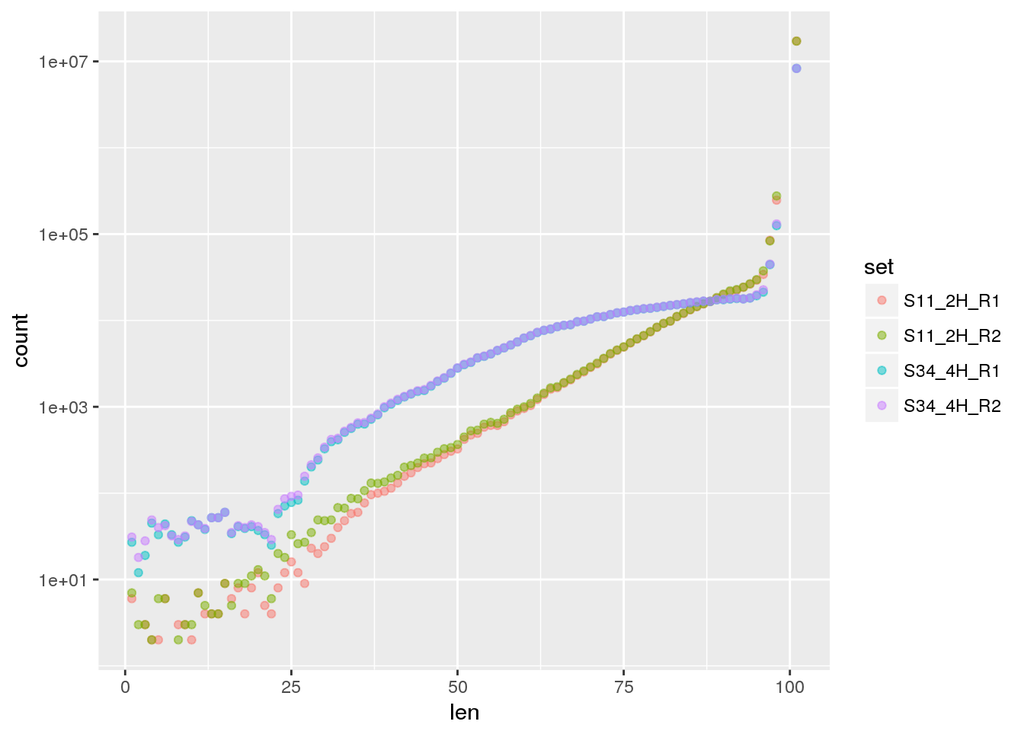

[figure not shown]

[figure not shown]

```r
len1=cbind(read.table('~/gdrive/School/bi624/ps1/11_2h_r1.len', col.names=c('count', 'len')), set='S11_2H_R1')
len2=cbind(read.table('~/gdrive/School/bi624/ps1/11_2h_r2.len', col.names=c('count', 'len')), set='S11_2H_R2')
len3=cbind(read.table('~/gdrive/School/bi624/ps1/34_4h_r1.len', col.names=c('count', 'len')), set='S34_4H_R1')
len4=cbind(read.table('~/gdrive/School/bi624/ps1/34_4h_r2.len', col.names=c('count', 'len')), set='S34_4H_R2')
lens=rbind(len1, len2, len3, len4)
ggplot(data=lens, mapping = aes(x=len, y=count, color=set))+
geom_point(alpha=0.5)+
scale_y_log10()
```

## (3) Comparison to Fragment Analysis

Briefly describe whether the adapter trimming results are consistent with the insert size distributions for your libraries. The size distribution information is in the Fragment Analyzer trace file on Github.

*No the results don’t appear to be consistant, as there isn’t enough insert of less of 100 to acount for all the trimming. Also I expected library 11 to have more trimming than 34 as it contained adapter dimmers*

# Part 3 – rRNA reads and strand-specificity

## (1) Proportion of Reads Aligning to rRNA

Find publicly available mouse rRNA sequences and generate a gsnap database from them. Align the SF-Seq reads to your mouse rRNA database and report the proportion of reads that likely came from rRNAs.

```
python ~/gdrive/lab_book/bio_info/fast_filter.py -g -r gene_biotype:rRNA -f ~/Downloads/Mus_musculus.GRCm38.ncrna.fa.gz > mus_rRNA.fa

easybuild  ifort/2017.1.132-GCC-6.3.0-2.27  impi/2017.1.132 GMAP-GSNAP/2017-06-20

gmap_build -d ensembl_rrna_mus.38 mus_rRNA.fa -D ~/gmap/

python ~/pairend_repair.py -1 trimmed_11_2H.1.fastq.gz -2 trimmed_11_2H.2.fastq.gz -g
python ~/pairend_repair.py -1 trimmed_34_4H.1.fastq.gz -2 trimmed_34_4H.2.fastq.gz -g

<!-- gsnap -D ~/gmap -d ensembl_rrna_mus.38 -N 1 -A sam -B 4 -m 20 -t 28 --split-output 11_2H_gsnap  ~/jobs/624_ps1/trimmed_11_2H.1.fastq.gz_repaired ~/jobs/624_ps1/trimmed_11_2H.2.fastq.gz_repaired --allow-pe-name-mismatch  --orientation=RF -->
gsnap -D ~/gmap -d ensembl_rrna_mus.38 -N 1 -A sam -B 4 -m 20 -t 28 --split-output 34_4H_gsnap  ~/jobs/624_ps1/trimmed_34_4H.1.fastq.gz_repaired ~/jobs/624_ps1/trimmed_34_4H.2.fastq.gz_repaired --allow-pe-name-mismatch --orientation=RF
```

```
wc 34_4H_gsnap.* -l
       364 34_4H_gsnap.concordant_mult
       358 34_4H_gsnap.concordant_transloc
       498 34_4H_gsnap.concordant_uniq
     23458 34_4H_gsnap.halfmapping_mult
       358 34_4H_gsnap.halfmapping_transloc
    151810 34_4H_gsnap.halfmapping_uniq
  17872002 34_4H_gsnap.nomapping
       358 34_4H_gsnap.paired_mult
       370 34_4H_gsnap.paired_uniq_inv
       358 34_4H_gsnap.paired_uniq_long
       508 34_4H_gsnap.paired_uniq_scr
       361 34_4H_gsnap.unpaired_mult
       358 34_4H_gsnap.unpaired_transloc
       496 34_4H_gsnap.unpaired_uniq
```

[output cut: 17 more lines]

*The total poroportion of reads mapped in someway to rRNA in 34_4H is 0.0099523*

*The total poroportion of reads mapped in someway to rRNA in 11_2H is 0.0583443*

## (2) Strand Specificity

Demonstrate convincingly that the SF-Seq data are from “strand-specific” RNA-Seq libraries. There are a number of possible strategies to address this problem, but you need only implement one. Report your evidence in numeric and graphical (e.g. a plot) forms.

*Prove strand specificity by mapping reads to ensembl cDNA using gmap, and look at how the reads are orientated in the alignment. The vast majority should be ‘+’*

[output not shown]

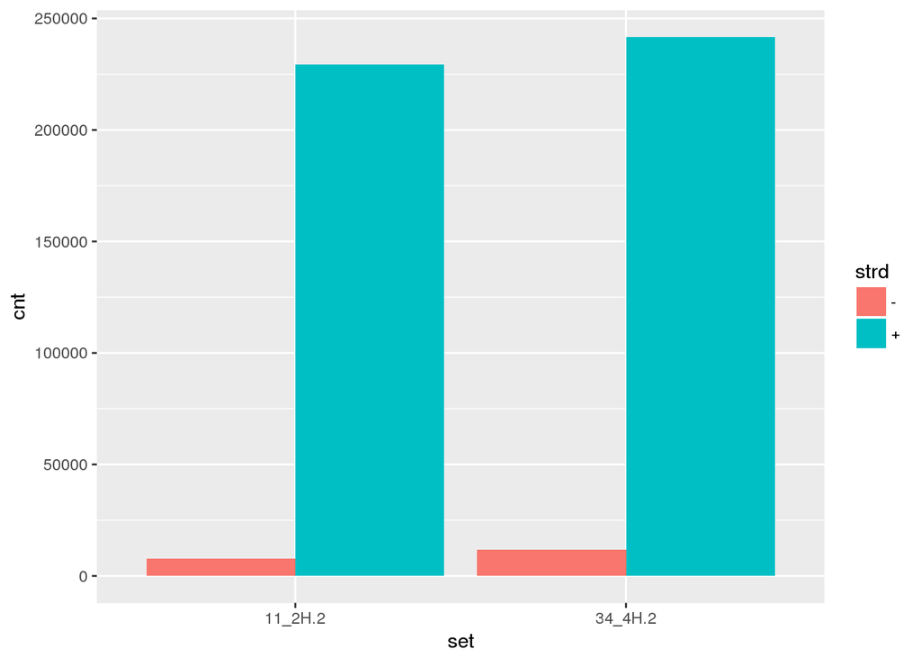

```r
strand=data.frame(set=c(rep('34_4H.2',2),rep('11_2H.2',2)), strd=c('+','-','+','-'), cnt=c(241696,11690,229356,7874))
ggplot(data = strand,mapping = aes(x=set,y=cnt, group=strd, fill=strd))+
    geom_col(position = 'dodge')
```